# Midterm assignment-predicting house price

Xiaoyi Wu, Yebei Yao

10/20/2021

# **01. Introduction & Motivation**

## 1.1 Brief introduction of Boulder County and the analysis background.

As the most-visited real estate website in the United States, Zillow and its affiliates offer customers an on-demand experience for selling, buying, renting and financing with transparency and nearly seamless end-to-end service. These years,Zillow have produced home value reports for the nation and over 130 metropolitan statistical areas. The reports identify market trends including, but not limited to: five and 10-year annualized change, negative equity, short sales and foreclosure transactions.

Hypothetically, in this project, Zillow has realized that its housing market predictions are not as accurate as they could be,because they do not factor in enough local intelligence. As such they have held a competition and asked our team to build a better predictive model of home prices for Boulder County, CO.

Real estate market is growing in Colorado year-over-year. Located in north-central Colorado, northwest of Denver, the county’s landscape includes several dense urban centers surrounded by rural buffer zones and mountain communities, plus portions of Rocky Mountain National Park.The namesake boulders are remnants from the last ice age, but some originated in the Rocky Mountains to the west. Bounder is quirky and weird, something that made it the perfect setting for the TV show “Mork and Mindy”.

Here are several main characteristic of Boulder county house market: **Close lacation with Denver**:The Boulder real estate market has all the earmarks of being sustainable. It has benefited a lot from its close proximity to Denver. The unemployment rate of Boulder city is well below the national average and with a strong economy to back it up, it will further drop in the coming years.

**abundant landscape features from farmland and rolling grasslands in the plains**Snug against the foothills where the Great Plains give rise to the Rocky Mountains, Boulder is nothing if not a looker. This city reveals its spectacle at the crest of a hill on U.S. Route 36 from Denver with its iconic sandstone slabs rising from the mountains, prefaced by pine-clad mesas and cradled within the backdrop of the snow-capped Indian Peaks. There are around 200 miles of hiking trails and massive amounts of green space.

**Livable metro areas**In the metro area, there are roughly 300,000 people.The destrict has seen growth as people move from the expensive, over-crowded Denver area to a city where you can still hike in the mountains and see the hills.Considering the satisfication residents are with their daily lives by metro area, and takes into account factors like crime, quality and availability of health care, quality of education and average commute time.It ranks second in Best Places to live for quality of life in U.S. News.

In the project, we adopted geospatial machine learning techniques, split the existing housing sale price data sets into training and test set, incorporated local intelligence features from Census data, public services and natural resources, also both Boulder county and Boulder city Open Data portal, as well as Open Street Map data, combined all those features and trained the final model,in order to achieve the lowest possible error rate. As result, our team has the Mean Absolute Errors(MAE) and the Mean Absolute Percent Errors (MAPE) is 194219.5 and 0.3088744 respectively.

## 1.2 Set up.

In this section, we load load necessary libraries,functions, plot theme options, map theme options, and identified functions of quantile breaks, and average nearest neighbor distance for future analysis.

# **02.Data Manipulation and Visualization**

## 2.2 Load data.

### 2.2.1 load house price and internal characteristics.

In this section, we load the data discribed above.

```r
setwd("E:/Class/MUSA508 public policy analytics/assignment/assignment-midterm/To do/mid_term-/handover")




boulder.s <- st_read('studentData.geojson',crs='ESRI:102254')


boulder.sf <-
  boulder.s %>%
 # st_as_sf(coords = c("Longitude", "Latitude"), crs = 'ESRI:102254', agr = "constant") %>%
  #st_transform('ESRI:102254') %>%
    mutate(bathnum=nbrThreeQtrBaths+nbrFullBaths
         +nbrHalfBaths)
```

### 2.2.2 load Boulder Base Data.

We load the geojson boulder boundary geometric data and transform its coordinate system identical to the boulder.sf, the data set contains houseprice information.

```r
boulder.boundary <-
  st_read("https://opendata.arcgis.com/datasets/964b8f3b3dbe401bb28d49ac93d29dc4_0.geojson") %>%
  st_transform(st_crs(boulder.sf))
```

### 2.2.3 load Amenity Data.

We load amenity data one by one and transform the coordinating system, cleaned the data living the geometry information, and deleted the rows with null information.

```r
## 01. Health facilities:

   #CDPHE Health Facilities and hospitals from open street map data.
Health_Facilities <-
  st_read('data/CDPHE_Health_Facilities.geojson')%>%
 st_transform(st_crs(boulder.sf))

   #Select health facilities which locate within Boulder County border.
Health_Facilities <- st_join(Health_Facilities, boulder.boundary,
                             join = st_intersects, left = FALSE)


Health_facility.sf <- Health_Facilities%>%
  select(geometry)%>%
  na.omit()%>%
  distinct()


##02.transit systems
#02.1Boulder Area Trails：Consolidated regional trails for the regional trails application.
Area_Trails <-
  st_read('data/Boulder_Area_Trails.geojson')%>%
  st_transform(st_crs(boulder.sf))

Area_Trails <- st_join(Area_Trails, boulder.boundary,
                             join = st_intersects, left = FALSE)

Area_Trails.sf <- Area_Trails%>%
  select(geometry)%>%
  na.omit()%>%
  distinct()

#02.2 Boulder traffic stations.
Traffic_stations <-
  st_read('data/Traffic_Stations.geojson')%>%
  st_transform(st_crs(boulder.sf))

Traffic_stations <- st_join(Traffic_stations, boulder.boundary,
                             join = st_intersects, left = FALSE)

Traffic_stations.sf <- Traffic_stations%>%
  select(geometry)%>%
  na.omit()%>%
  distinct()

#03.open space
Openspace <-
  st_read('data/County_Open_Space.geojson')%>%
  st_transform(st_crs(boulder.sf))

#Select open spaces which locate within Boulder County border.
Openspace <- st_join(Openspace, boulder.boundary,
                             join = st_intersects, left = FALSE)




#clean openspace
Openspace.sf <-
  Openspace %>%
  select(geometry)%>%
    na.omit() %>%
    st_transform(st_crs(boulder.sf))  %>%
    distinct()

#04.libraries
Libraries <-
  st_read('data/Libraries.geojson')

#clean libraries
Libraries.sf <-
  Libraries %>%
  select(geometry)%>%
    na.omit() %>%
    st_as_sf(coords = c("geometry"), crs = 4326, agr = "constant") %>%
    st_transform(st_crs(boulder.sf))  %>%
    distinct()

#05.Landmark
landmark01 <- st_read('data/landmark01.geojson')%>%
 st_transform(st_crs(boulder.sf))

landmark02 <- st_read('data/landmark02.geojson')%>%
 st_transform(st_crs(boulder.sf))

landmark <- st_join(landmark01,landmark02,join = st_intersects, left = TRUE)%>%
  select(geometry)%>%
  na.omit() %>%
  distinct()

#06.school
school <-
  st_read('E:\\Class\\MUSA508 public policy analytics\\assignment\\assignment-midterm\\To do\\mid_term-\\handover\\data\\school.csv') %>%

  mutate(x = gsub("[c()]", "",geometry)) %>%
    separate(x,into= c("Y","X"), sep=",") %>%
    mutate(X = as.numeric(X),Y = as.numeric(Y)) %>%
    drop_na(X) %>%
    st_as_sf(coords = c("Y", "X"), crs = 4326)%>%
  st_transform('ESRI:102254')

#clean school data
school.sf<-school%>%
 select(geometry)%>%
  na.omit()%>%
  distinct()

#mapview::mapview(school.sf)

#07.restaurant
restaurant <-
st_read('E:\\Class\\MUSA508 public policy analytics\\assignment\\assignment-midterm\\To do\\mid_term-\\handover\\data\\restaurant.csv') %>%
  mutate(x = gsub("[c()]", "",geometry)) %>%
    separate(x,into= c("Y","X"), sep=" ") %>%
    mutate(X = as.numeric(X),Y = as.numeric(Y)) %>%
    drop_na(X) %>%
    st_as_sf(coords = c("Y", "X"), crs = 4326)%>%
  st_transform('ESRI:102254')

#clean restaurant
restaurant.sf <- restaurant%>%
  select(geometry)%>%
  na.omit()%>%
  distinct()
#mapview::mapview(restaurant.sf)


#08.theater
theater <-
st_read('E:\\Class\\MUSA508 public policy analytics\\assignment\\assignment-midterm\\To do\\mid_term-\\handover\\data\\theater.csv') %>%
  mutate(x = gsub("[c()]", "",geometry)) %>%
    separate(x,into= c("Y","X"), sep=" ") %>%
    mutate(X = as.numeric(X),Y = as.numeric(Y)) %>%
    drop_na(X) %>%
    st_as_sf(coords = c("Y", "X"), crs = 4326)%>%
  st_transform('ESRI:102254')

#clean theater
theater.sf <- theater%>%
  select(geometry)%>%
  na.omit()%>%
  distinct()

#mapview::mapview(theater.sf)
```

### 2.2.4 Loading census tract data.

We loaded census data in this section and projected it with the same coordinate system with former data.

```r
census_api_key("9e5876bd913ec7705eb4b93ee17937abb9bf8d2b")

tracts2019 <- get_acs(geography = "tract", variables = c("B25026_001E","B02001_002E",
                                             "B19013_001E","B25058_001E",
                                             "B06012_002E",
                                             # vacant variables
                                             "B25002_003E",
                                             "B25004_002E","B25004_003E",
                                             "B25004_004E","B25004_005E",
                                             # total housing unit
                                             "B25001_001E",
                                             # renter occupied
                                             'B08137_003E'),
          year=2019, state= 08, county= 013, geometry=T, output="wide") %>%
  st_transform(st_crs(boulder.sf)) %>%
  rename(TotalPop = B25026_001E,
         Whites = B02001_002E,
         MedHHInc = B19013_001E,
         MedRent = B25058_001E,
         TotalPoverty = B06012_002E,
         TotalVacant = B25002_003E,
         ForRent = B25004_002E,
         ForRentVac = B25004_003E,
         ForSale = B25004_004E,
         ForSaleVac = B25004_005E,
         TotalUnit = B25001_001E,
         RenterOccupied = B08137_003E
         ) %>%
  dplyr::select(-NAME, -starts_with("B")) %>%
  mutate(pctWhite = ifelse(TotalPop > 0, Whites / TotalPop,0),
         pctPoverty = ifelse(TotalPop > 0, TotalPoverty / TotalPop, 0),
         pctTotalVacant = ifelse(TotalUnit > 0, TotalVacant / TotalUnit * 100, 0),
         TotalOccupied = TotalUnit - TotalVacant,
        pctRenterOccupied = ifelse(TotalOccupied >0, RenterOccupied/TotalOccupied, 0)) %>%
  dplyr::select(-Whites, -TotalPoverty)



projected.tracts2019 <-
    tracts2019 %>%
 st_transform(st_crs(boulder.sf))

#mapview(projected.tracts2019)
```

### 2.2.5 Feature engineering.

Feature engineering is the process of transforming raw data into features that better represent the underlying problem to the predictive models, which will be helpful to improve the accuracy on our prediction.

In this case,When considering the effect of amenity features to the house price, we have to measure the accessibility,in other words, the exposure the houses locations to the amenities locations.

```r
st_c <- st_coordinates

boulder.sf <-
  boulder.sf %>%
    mutate(
      health_nn1 = nn_function(st_c(boulder.s), st_c(Health_facility.sf), 1),
      health_nn2 = nn_function(st_c(boulder.s), st_c(Health_facility.sf), 2),
      health_nn3 = nn_function(st_c(boulder.s), st_c(Health_facility.sf), 3),
      health_nn4 = nn_function(st_c(boulder.s), st_c(Health_facility.sf), 4),
      health_nn5 = nn_function(st_c(boulder.s), st_c(Health_facility.sf), 5))


boulder.sf <-
  boulder.sf %>%
    mutate(
      library_nn1 = nn_function(st_c(boulder.sf), st_c(Libraries.sf), 1),
      library_nn2 = nn_function(st_c(boulder.sf), st_c(Libraries.sf), 2),
      library_nn3 = nn_function(st_c(boulder.sf), st_c(Libraries.sf), 3))


boulder.sf <-
  boulder.sf %>%
    mutate(
      Tra_station_nn1 = nn_function(st_c(boulder.sf), st_c(st_centroid(Traffic_stations.sf)), 1),
      Tra_station_nn2 = nn_function(st_c(boulder.sf), st_c(st_centroid(Traffic_stations.sf)), 2),
      Tra_station_nn3 = nn_function(st_c(boulder.sf), st_c(st_centroid(Traffic_stations.sf)), 3),
      Tra_station_nn4 = nn_function(st_c(boulder.sf), st_c(st_centroid(Traffic_stations.sf)), 4),
      Tra_station_nn5 = nn_function(st_c(boulder.sf), st_c(st_centroid(Traffic_stations.sf)), 5))

boulder.sf <-
  boulder.sf %>%
    mutate(
      Openspace_nn1 = nn_function(st_c(boulder.sf), st_c(st_centroid(Openspace.sf)), 1),
      Openspace_nn2 = nn_function(st_c(boulder.sf), st_c(st_centroid(Openspace.sf)), 2),
      Openspace_nn3 = nn_function(st_c(boulder.sf), st_c(st_centroid(Openspace.sf)), 3),
      Openspace_nn4 = nn_function(st_c(boulder.sf), st_c(st_centroid(Openspace.sf)), 4),
      Openspace_nn5 = nn_function(st_c(boulder.sf), st_c(st_centroid(Openspace.sf)), 5))


boulder.sf <-
  boulder.sf %>%
    mutate(
      Area_Trail_nn1 = nn_function(st_c(boulder.sf), st_c(st_centroid(Area_Trails.sf)), 1),
      Area_Trail_nn2 = nn_function(st_c(boulder.sf), st_c(st_centroid(Area_Trails.sf)), 2),
      Area_Trail_nn3 = nn_function(st_c(boulder.sf), st_c(st_centroid(Area_Trails.sf)), 3),
      Area_Trail_nn4 = nn_function(st_c(boulder.sf), st_c(st_centroid(Area_Trails.sf)), 4),
      Area_Trail_nn5 = nn_function(st_c(boulder.sf), st_c(st_centroid(Area_Trails.sf)), 5))

boulder.sf <-
  boulder.sf %>%
    mutate(
      landmark_nn1 = nn_function(st_c(boulder.sf), st_c(st_centroid(landmark)), 1),
      landmark_nn2 = nn_function(st_c(boulder.sf), st_c(st_centroid(landmark)), 2),
      landmark_nn3 = nn_function(st_c(boulder.sf), st_c(st_centroid(landmark)), 3),
      landmark_nn4 = nn_function(st_c(boulder.sf), st_c(st_centroid(landmark)), 4),
      landmark_nn5 = nn_function(st_c(boulder.sf), st_c(st_centroid(landmark)), 5))


boulder.sf <-
  boulder.sf %>%
    mutate(
      school_nn1 = nn_function(st_c(boulder.sf), st_c(school.sf), 1),
      school_nn2 = nn_function(st_c(boulder.sf), st_c(school.sf), 2),
      school_nn3 = nn_function(st_c(boulder.sf), st_c(school.sf), 3),
      school_nn4 = nn_function(st_c(boulder.sf), st_c(school.sf), 4),
      school_nn5 = nn_function(st_c(boulder.sf), st_c(school.sf), 5))


boulder.sf <-
  boulder.sf %>%
    mutate(
      theater_nn1 = nn_function(st_c(boulder.sf), st_c(theater.sf), 1),
      theater_nn2 = nn_function(st_c(boulder.sf), st_c(theater.sf), 2),
      theater_nn3 = nn_function(st_c(boulder.sf), st_c(theater.sf), 3),
      theater_nn4 = nn_function(st_c(boulder.sf), st_c(theater.sf), 4),
      theater_nn5 = nn_function(st_c(boulder.sf), st_c(theater.sf), 5))

boulder.sf <-
  boulder.sf %>%
    mutate(
      restaurant_nn1 = nn_function(st_c(boulder.sf), st_c(restaurant.sf), 1),
      restaurant_nn2 = nn_function(st_c(boulder.sf), st_c(restaurant.sf), 2),
      restaurant_nn3 = nn_function(st_c(boulder.sf), st_c(restaurant.sf), 3),
      restaurant_nn4 = nn_function(st_c(boulder.sf), st_c(restaurant.sf), 4),
      restaurant_nn5 = nn_function(st_c(boulder.sf), st_c(restaurant.sf), 5))
```

### 2.2.6 combine the data with tracts and split dataset by “toPredict”

When combining census tract data with the house price data, the census features will be added into the house price dataset, which could be helpful to the following feature extraction work. In order to make the computer find house price pattern,we split the houseprice by “toPredict”column for modeling and future predicting.

```r
index <- boulder.sf %>%
  rowid_to_column(var = "rowIndex")

boulder.sf <-st_join(index, projected.tracts2019) %>%
  distinct(rowIndex, .keep_all = TRUE)

nhoods<-projected.tracts2019%>%
  dplyr::select(GEOID,geometry)

index.neigh <-st_join(index,nhoods) %>%
  distinct(rowIndex, .keep_all = TRUE)


train_data<- filter(boulder.sf,toPredict==0)
test_data<- filter(boulder.sf,toPredict==1)
```

## 2.3 summary statistics of features

### 2.3.1 All potential features

At this time, we combined all the features into one table,and subdivided it into four categories.All in all, there is **74** features in the all feature list.

```r
#write.csv(x = train_data,file = "train_data.csv")

all.feature.list <- boulder.sf %>%
   dplyr:: select(
  -Ac,-AcDscr,-address,-bld_num,-bldgClass,-bldgClassDscr,-bsmtType,-bsmtTypeDscr,-carStorageType,
    -carStorageTypeDscr,-CompCode,-ConstCode,-ConstCodeDscr,-designCodeDscr,-starts_with("ExtWall"),-Heating,-HeatingDscr,-IntWall,-IntWallDscr,-nbrHalfBaths,-qualityCodeDscr,-Roof_Cover,-Roof_CoverDscr,-saleDate,-section_num,-status_cd,-Stories,-UnitCount,-year,-year_quarter
)%>%
st_drop_geometry()
```

### 2.3.2 Internal features

The internal features are the characteristics of the house itself, we selected **11** internal features and they are presented below.

```r
internal.feature.list <- all.feature.list %>%
   dplyr::select(builtYear,bsmtSF,carStorageSF,nbrRoomsNobath,nbrThreeQtrBaths,nbrFullBaths,
                  qualityCode,EffectiveYear,nbrBedRoom,mainfloorSF,designCode)

stargazer(internal.feature.list, type = "html",
          title = "Table DATA 2.3.2 Summary Statistics of Internal Characteristics ",
          header = FALSE,
          single.row = TRUE)
```

**Table DATA 2.3.2 Summary Statistics of Internal Characteristics**

| Statistic | N | Mean | St. Dev. | Min | Pctl(25) | Pctl(75) | Max |
| --- | --- | --- | --- | --- | --- | --- | --- |
| builtYear | 11,364 | 1,987.177 | 26.770 | 1,860 | 1,972 | 2,006 | 2,021 |
| bsmtSF | 11,364 | 743.729 | 627.363 | 0 | 133.8 | 1,125 | 4,534 |
| carStorageSF | 11,364 | 471.891 | 235.855 | 0 | 380 | 600 | 3,040 |
| nbrRoomsNobath | 11,364 | 7.391 | 2.136 | 0 | 6 | 9 | 28 |
| nbrThreeQtrBaths | 11,364 | 0.616 | 0.729 | 0 | 0 | 1 | 9 |
| nbrFullBaths | 11,364 | 1.782 | 0.873 | 0 | 1 | 2 | 12 |
| qualityCode | 11,364 | 37.312 | 7.874 | 10 | 30 | 41 | 80 |
| EffectiveYear | 11,364 | 1,997.694 | 17.462 | 1,879 | 1,989 | 2,010 | 2,021 |
| nbrBedRoom | 11,364 | 3.445 | 1.051 | 0 | 3 | 4 | 24 |
| mainfloorSF | 11,364 | 1,313.513 | 607.191 | 0 | 923 | 1,619 | 7,795 |

### 2.3.3 Feature:amenities/public services

The amenity and public features are the ones discribe average exposure to current point, linear, and polygon features spread around the county.In total, there are **43** features.

```r
amenity_feature.list <- all.feature.list %>%
  dplyr:: select(
    starts_with('health_'),starts_with('landmark_'),starts_with('Openspace'),starts_with('Area_Trail'),starts_with('Tra_station'),starts_with('restaurant'),starts_with('theater'),starts_with('school'),starts_with('library_'))

stargazer(amenity_feature.list, type = "html",
          title = "Table DATA 2.3.3 Summary Statistics of Amenities/Public Services ",
          header = FALSE,
          single.row = TRUE)
```

**Table DATA 2.3.3 Summary Statistics of Amenities/Public Services**

| Statistic | N | Mean | St. Dev. | Min | Pctl(25) | Pctl(75) | Max |
| --- | --- | --- | --- | --- | --- | --- | --- |
| health_nn1 | 11,364 | 1,538.660 | 2,732.710 | 15.588 | 484.124 | 1,482.415 | 29,521.240 |
| health_nn2 | 11,364 | 1,891.225 | 3,038.604 | 48.873 | 677.154 | 1,751.943 | 30,417.830 |
| health_nn3 | 11,364 | 2,182.743 | 3,221.901 | 126.749 | 814.754 | 2,181.459 | 30,852.560 |
| health_nn4 | 11,364 | 2,389.698 | 3,359.207 | 204.111 | 907.394 | 2,458.852 | 31,503.850 |
| health_nn5 | 11,364 | 2,554.452 | 3,456.215 | 319.129 | 998.423 | 2,647.748 | 31,929.420 |
| landmark_nn1 | 11,364 | 5,566.924 | 2,589.086 | 81.627 | 3,347.104 | 7,462.473 | 13,406.980 |
| landmark_nn2 | 11,364 | 6,229.062 | 2,650.153 | 391.486 | 4,079.031 | 8,210.132 | 13,679.670 |
| landmark_nn3 | 11,364 | 6,666.414 | 2,668.977 | 750.926 | 4,546.525 | 8,708.437 | 14,073.500 |
| landmark_nn4 | 11,364 | 7,040.854 | 2,644.846 | 1,016.228 | 4,987.968 | 9,063.446 | 14,780.940 |
| landmark_nn5 | 11,364 | 7,438.655 | 2,652.127 | 1,275.212 | 5,334.299 | 9,479.676 | 15,273.730 |
| Openspace_nn1 | 11,364 | 1,208.865 | 900.566 | 0.001 | 540.843 | 1,635.252 | 4,622.394 |
| Openspace_nn2 | 11,364 | 1,312.212 | 898.467 | 39.258 | 639.134 | 1,726.329 | 4,636.573 |
| Openspace_nn3 | 11,364 | 1,430.938 | 945.979 | 67.810 | 730.500 | 1,838.914 | 4,658.113 |
| Openspace_nn4 | 11,364 | 1,528.323 | 981.074 | 80.564 | 800.482 | 1,948.879 | 4,672.661 |
| Openspace_nn5 | 11,364 | 1,613.078 | 1,010.873 | 94.896 | 871.562 | 2,039.964 | 4,788.639 |
| Area_Trail_nn1 | 11,364 | 366.126 | 663.345 | 2.934 | 111.844 | 332.235 | 5,827.825 |
| Area_Trail_nn2 | 11,364 | 420.427 | 736.716 | 14.634 | 144.515 | 367.096 | 6,045.029 |
| Area_Trail_nn3 | 11,364 | 458.829 | 779.922 | 15.278 | 167.085 | 403.278 | 6,564.452 |
| Area_Trail_nn4 | 11,364 | 490.629 | 806.861 | 16.722 | 187.646 | 433.005 | 6,909.735 |
| Area_Trail_nn5 | 11,364 | 518.926 | 829.289 | 17.750 | 205.762 | 466.750 | 7,119.151 |
| Tra_station_nn1 | 11,364 | 1,738.240 | 1,085.907 | 30.247 | 970.904 | 2,274.394 | 7,327.472 |
| Tra_station_nn2 | 11,364 | 1,977.444 | 1,095.632 | 83.048 | 1,241.926 | 2,545.660 | 7,925.004 |
| Tra_station_nn3 | 11,364 | 2,176.058 | 1,082.448 | 101.082 | 1,474.395 | 2,706.834 | 8,212.468 |
| Tra_station_nn4 | 11,364 | 2,353.388 | 1,077.889 | 184.553 | 1,651.985 | 2,877.798 | 8,383.683 |
| Tra_station_nn5 | 11,364 | 2,503.497 | 1,080.980 | 266.809 | 1,787.322 | 3,024.294 | 8,570.707 |
| restaurant_nn1 | 11,364 | 1,296.297 | 1,244.614 | 10.494 | 580.257 | 1,579.500 | 10,897.640 |
| restaurant_nn2 | 11,364 | 1,416.033 | 1,354.925 | 24.216 | 631.228 | 1,749.325 | 10,899.980 |
| restaurant_nn3 | 11,364 | 1,479.703 | 1,444.359 | 26.567 | 658.565 | 1,793.953 | 11,193.450 |
| restaurant_nn4 | 11,364 | 1,523.997 | 1,493.812 | 27.609 | 687.547 | 1,822.907 | 11,426.600 |
| restaurant_nn5 | 11,364 | 1,588.619 | 1,528.731 | 29.231 | 722.389 | 1,941.406 | 11,566.820 |
| theater_nn1 | 11,364 | 5,718.254 | 4,440.235 | 64.837 | 2,347.022 | 8,256.722 | 32,477.510 |
| theater_nn2 | 11,364 | 6,022.968 | 4,396.115 | 68.386 | 2,667.245 | 8,608.087 | 32,479.600 |
| theater_nn3 | 11,364 | 6,125.506 | 4,391.696 | 71.829 | 2,771.316 | 8,809.035 | 32,483.670 |
| theater_nn4 | 11,364 | 6,177.848 | 4,391.205 | 74.388 | 2,834.214 | 8,875.550 | 32,486.290 |
| theater_nn5 | 11,364 | 6,210.023 | 4,391.389 | 76.377 | 2,860.739 | 8,918.537 | 32,489.170 |
| school_nn1 | 11,364 | 1,204.792 | 1,945.652 | 16.529 | 359.080 | 1,238.887 | 23,382.880 |
| school_nn2 | 11,364 | 1,302.453 | 2,140.118 | 18.454 | 388.307 | 1,384.399 | 23,384.890 |
| school_nn3 | 11,364 | 1,345.578 | 2,216.568 | 26.993 | 406.616 | 1,422.846 | 23,389.880 |
| school_nn4 | 11,364 | 1,373.760 | 2,256.298 | 34.628 | 420.063 | 1,477.276 | 23,402.540 |
| school_nn5 | 11,364 | 1,396.393 | 2,280.669 | 36.615 | 433.644 | 1,526.058 | 23,411.620 |
| library_nn1 | 11,364 | 3,253.564 | 2,387.551 | 51.215 | 1,558.117 | 4,150.548 | 21,165.380 |
| library_nn2 | 11,364 | 4,502.923 | 2,626.955 | 276.934 | 2,585.264 | 5,840.899 | 22,232.650 |
| library_nn3 | 11,364 | 6,686.811 | 2,960.604 | 346.631 | 4,916.125 | 8,511.911 | 25,972.640 |

### 2.3.4 spatial features:census feature list

spatial features are spatial data contains geometry information. census features are the one of them. We filter out the unnecessary features or the ones may be inter-correlated, and there are **5** features left.

```r
census.feature.list <- all.feature.list %>%
  dplyr:: select(pctRenterOccupied,pctTotalVacant,pctWhite,TotalUnit,MedHHInc)


stargazer(census.feature.list, type = "html",
          title = "Table DATA 2.3.4 Spatial Feature: Census Data ",
          header = FALSE,
          single.row = TRUE)
```

**Table DATA 2.3.4 Spatial Feature: Census Data**

| Statistic | N | Mean | St. Dev. | Min | Pctl(25) | Pctl(75) | Max |
| --- | --- | --- | --- | --- | --- | --- | --- |
| pctRenterOccupied | 11,364 | 0.406 | 0.235 | 0.071 | 0.261 | 0.521 | 1.373 |
| pctTotalVacant | 11,364 | 5.514 | 8.131 | 0.000 | 1.442 | 6.299 | 71.268 |
| pctWhite | 11,364 | 0.907 | 0.074 | 0.749 | 0.877 | 0.933 | 3.329 |
| TotalUnit | 11,364 | 2,489.315 | 1,007.377 | 577 | 1,753 | 3,083 | 4,483 |
| MedHHInc | 11,364 | 97,719.920 | 25,091.390 | 23,699 | 82,398 | 120,717 | 173,500 |

### 2.3.5 spatial structure:Neighborhood

This section, we counted the number of houses in each neighborhood. in this project, we use the census tract as the neighborhood, the GEOID of each census tract is the unit.

```r
spatial.feature.list <- all.feature.list %>%
  dplyr:: select(GEOID)

as.data.frame(table(spatial.feature.list)) %>%
  rename(`Neighborhood List` = spatial.feature.list,
         Number =Freq) %>%
  kable(caption = 'Table DATA 2.3.5 Spatial Feature: Neighborhood') %>%
  kable_styling("striped", full_width = F)
```

Table DATA 2.3.5 Spatial Feature: Neighborhood

| Neighborhood List | Number |
| --- | --- |
| 08013012101 | 190 |
| 08013012102 | 231 |
| 08013012103 | 106 |
| 08013012104 | 101 |
| 08013012105 | 113 |
| 08013012201 | 76 |
| 08013012202 | 41 |
| 08013012203 | 100 |
| 08013012204 | 18 |
| 08013012300 | 2 |
| 08013012401 | 73 |
| 08013012501 | 52 |
| 08013012505 | 137 |
| 08013012507 | 111 |
| 08013012508 | 61 |
| 08013012509 | 112 |
| 08013012510 | 120 |
| 08013012511 | 52 |
| 08013012603 | 109 |
| 08013012605 | 6 |
| 08013012607 | 19 |
| 08013012608 | 79 |
| 08013012701 | 166 |
| 08013012705 | 47 |
| 08013012707 | 39 |
| 08013012708 | 227 |
| 08013012709 | 62 |
| 08013012710 | 117 |
| 08013012800 | 1176 |
| 08013012903 | 100 |
| 08013012904 | 267 |
| 08013012905 | 71 |
| 08013012907 | 186 |
| 08013013003 | 281 |
| 08013013004 | 109 |
| 08013013005 | 123 |
| 08013013006 | 208 |
| 08013013201 | 54 |
| 08013013202 | 31 |
| 08013013205 | 208 |
| 08013013207 | 121 |
| 08013013208 | 179 |
| 08013013210 | 198 |
| 08013013211 | 525 |
| 08013013212 | 305 |
| 08013013213 | 489 |
| 08013013302 | 222 |
| 08013013305 | 188 |
| 08013013306 | 116 |
| 08013013307 | 118 |
| 08013013308 | 133 |
| 08013013401 | 107 |
| 08013013402 | 246 |
| 08013013503 | 145 |
| 08013013505 | 63 |
| 08013013506 | 246 |
| 08013013507 | 138 |
| 08013013508 | 487 |
| 08013013601 | 134 |
| 08013013602 | 114 |
| 08013013701 | 324 |
| 08013013702 | 333 |
| 08013060600 | 242 |
| 08013060700 | 96 |
| 08013060800 | 165 |
| 08013060900 | 205 |
| 08013061300 | 123 |
| 08013061400 | 221 |

## 2.4 correlation of features

After all the potential related features are set,we have to make several exploratory analysis so as to decide which features can better predict the houseprice. The correlation of those features to the price is quite essential in this way.We use both correlation matrix and correlation scatterplots to visualize those correlationships.

*Correlation matrix, in this process,we calculate bivariate correlation and statistical significance, respectively. After drawing all the features,we make detailed correlation matrix for different types of features. In the following figures 2.4.1 to 2.4.4,blue indicates positive correlation between two features, while green indicates negative correlations.And the dark the color is, the stronger correlationship is.

*correlation scatterplots:with the scatterplots, we can illustrate price as a function of continuous variables, and visualize the direct relationship between house price and the potential features.

### 2.4.1 All feature correlation matrix

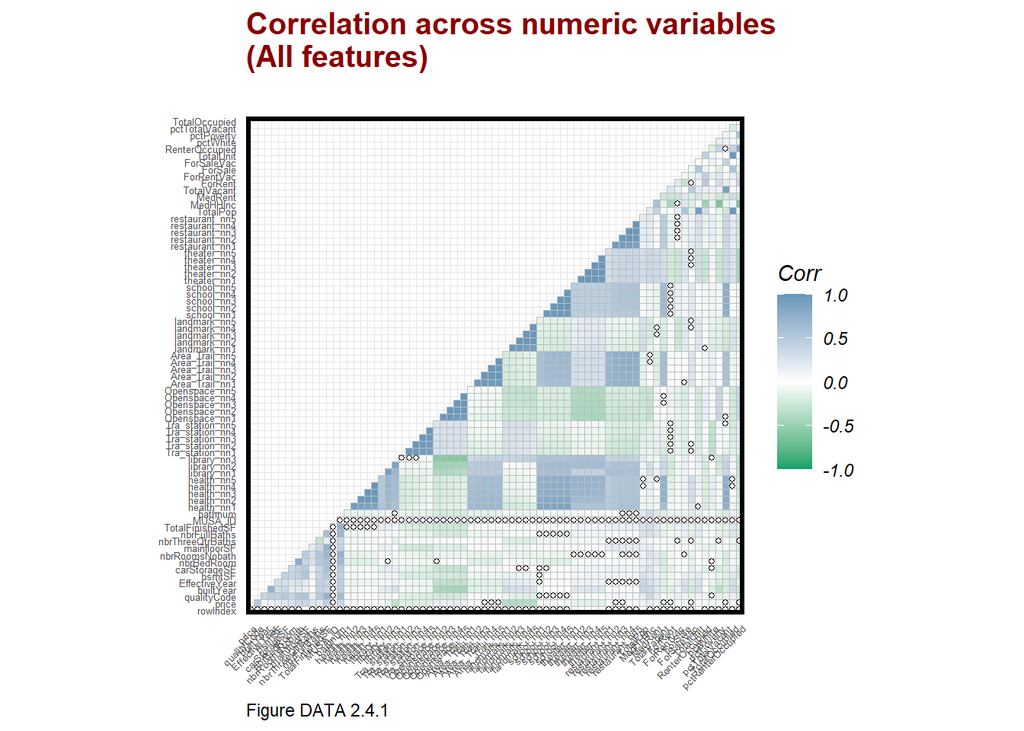

```r
numericVars.all<-
  select_if(all.feature.list,is.numeric)%>%
  na.omit()

ggcorrplot(
  round(cor(numericVars.all), 2),
  p.mat = cor_pmat(numericVars.all),
  colors = c('#05A167', "white", '#6897BB'),
  lab_size = 1,
  tl.cex = 5,
  type="lower",
  insig = c("pch", "blank"), pch = 1, pch.col = "black", pch.cex =1) +
  labs(title = "Correlation across numeric variables\n(All features)\n",
       caption = 'Figure DATA 2.4.1') +
  plotTheme()
```

### 2.4.2 Amenity feature correlation matrix

From the matrix below, we can see that some of the amenity features are correlated, the health facility and the restaurant,school has positive correlation, the school have positive correlation with the theater. The distance with the traffic station and the schools are negatively correlated, which means the further the house to the transit station,the less chance there are schools. The correlation plot corresponds to our daily experience.

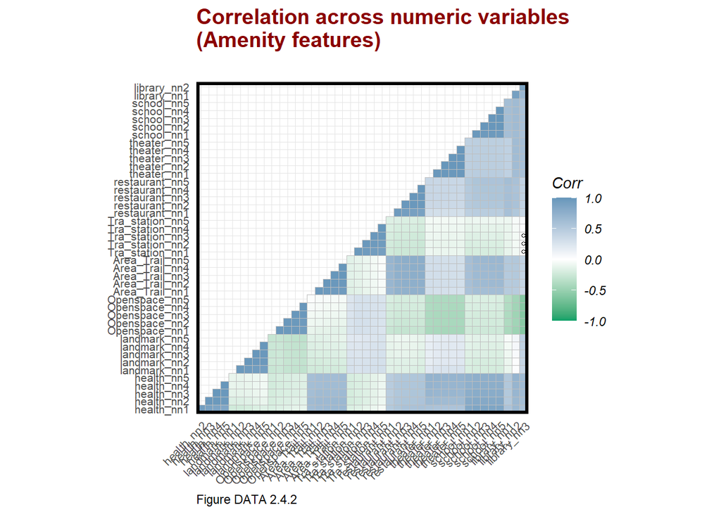

```r
numericVars.Amenity<-
  select_if(amenity_feature.list,is.numeric)%>%
  na.omit()

ggcorrplot(
  round(cor(numericVars.Amenity), 2),
  p.mat = cor_pmat(numericVars.Amenity),
  colors = c('#05A167', "white", '#6897BB'),
  lab_size = 1,
  tl.cex = 8,
  type="lower",
  insig = c("pch", "blank"), pch = 1, pch.col = "black", pch.cex =1) +
  labs(title = "Correlation across numeric variables\n(Amenity features)\n",
       caption = 'Figure DATA 2.4.2') +
  plotTheme()
```

### 2.4.3 Internal feature correlation matrix

From the matrix, we can see that most internal features are positively correlated with each other.

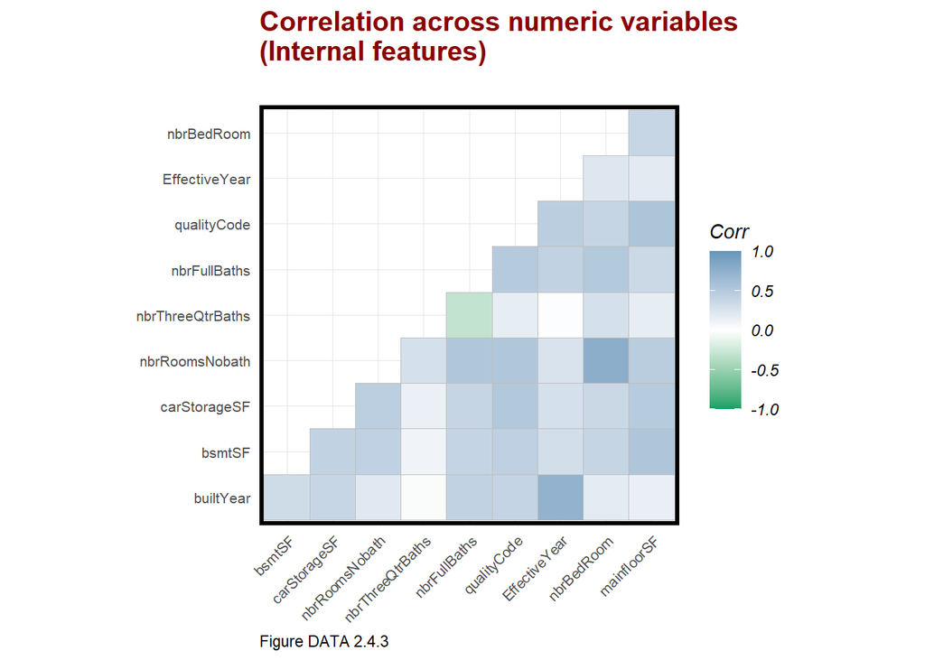

```r
numericVars.Internal<-
  select_if(internal.feature.list,is.numeric)%>%
  na.omit()

ggcorrplot(
  round(cor(numericVars.Internal), 2),
  p.mat = cor_pmat(numericVars.Internal),
  colors = c('#05A167', "white", '#6897BB'),
  lab_size = 1,
  tl.cex = 8,
  type="lower",
  insig = c("pch", "blank"), pch = 1, pch.col = "black", pch.cex =1) +
  labs(title = "Correlation across numeric variables\n(Internal features)\n",
       caption = 'Figure DATA 2.4.3') +
  plotTheme()
```

### 2.4.4 Census feature correlation matrix

from the matrix of census features below, we can see that the medium house income and the porpotion of renter living in the house have strongly negative correlation,which means the more renters living in the house, the less income the house hold will receive. maybe it’s because the relatively wealthy person tend to buy house rather than rent one.

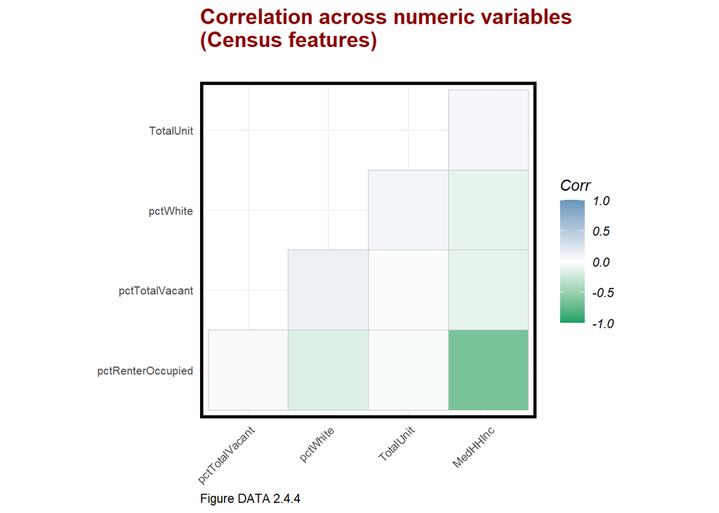

```r
numericVars.Census<-
  select_if(census.feature.list,is.numeric)%>%
  na.omit()

ggcorrplot(
  round(cor(numericVars.Census), 2),
  p.mat = cor_pmat(numericVars.Census),
  colors = c('#05A167', "white", '#6897BB'),
  lab_size = 1,
  tl.cex = 8,
  type="lower",
  insig = c("pch", "blank"), pch = 1, pch.col = "black", pch.cex =1) +
  labs(title = "Correlation across numeric variables\n(Census features)\n",
       caption = 'Figure DATA 2.4.4') +
  plotTheme()
```

### 2.4.5 home price as a function of four numeric features.

From those four scatter plots, we choose “percentage of white people”,“number of bedroom”,“the quality code”,“number of main floor” as interested features. The result shows that the relationship of price and percent of white people is not very intuitive. One explanation may be white people reside evenly and consist of a huge portion of Boulder county diversity, which makes little difference to the whole city. The result also shows that the relationship between house price and the main floor square is positive, which fits our daily experience.

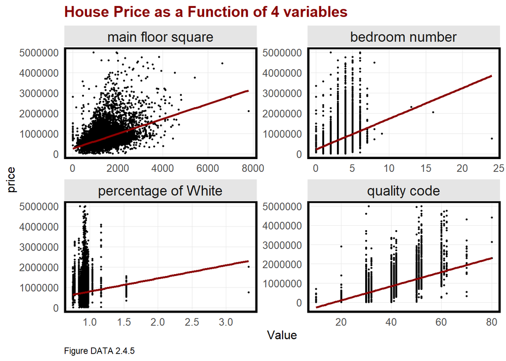

```r
features <- c('percentage of White','bedroom number','quality code','main floor square')
names(features)<-c('pctWhite','nbrBedRoom','qualityCode','mainfloorSF')

price.house.plot <-
  st_drop_geometry(train_data) %>%
  dplyr::select(price, pctWhite, nbrBedRoom,qualityCode,mainfloorSF) %>%
  filter(price <= 5000000) %>%
  gather(Variable, Value, -price) %>%
  ggplot(aes(Value, price)) +
  geom_point(size = .5) +
  geom_smooth(method = "lm", se=F, colour = "darkred") +
  facet_wrap(~Variable, ncol = 2, scales = "free",
             labeller = labeller(Variable = features)) +
  plotTheme() +
  labs(title = "House Price as a Function of 4 variables",
       caption = 'Figure DATA 2.4.5')
price.house.plot
```

### 2.4.6 home price as a function of trasit stations.

From scatter plot below,we take house price as a function of the average distance of five nearest transit stations. It is obvious that the longer distance the house to the transit station, the lower the house price is,which fits the daily experience.

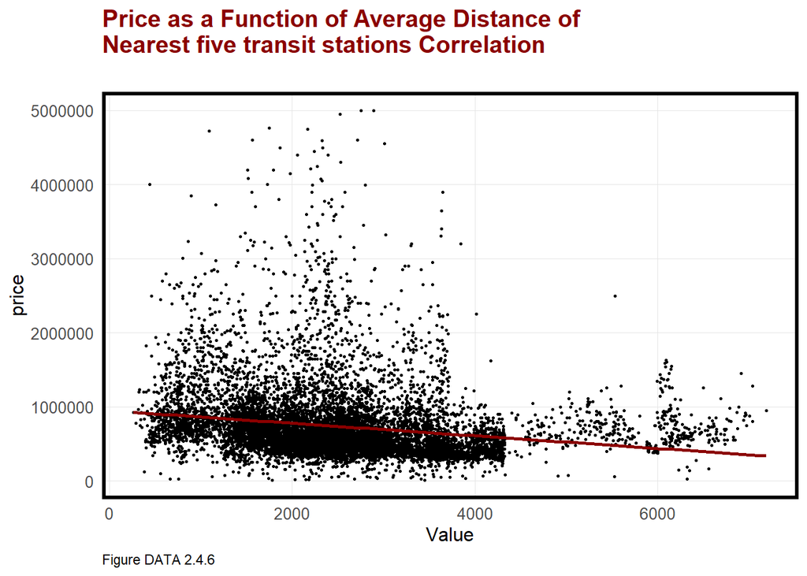

```r
price.tra_station.plot <-
  st_drop_geometry(train_data) %>%
  dplyr::select(price, Tra_station_nn5 ) %>%
  filter(price <= 5000000) %>%
  gather(Variable, Value, -price) %>%
  ggplot(aes(Value, price)) +
  geom_point(size = .5) +
  geom_smooth(method = "lm", se=F, colour = "darkred") +
  labs(title = "Price as a Function of Average Distance of\nNearest five transit stations Correlation\n",
       caption = 'Figure DATA 2.4.6') +
  plotTheme()
price.tra_station.plot
```

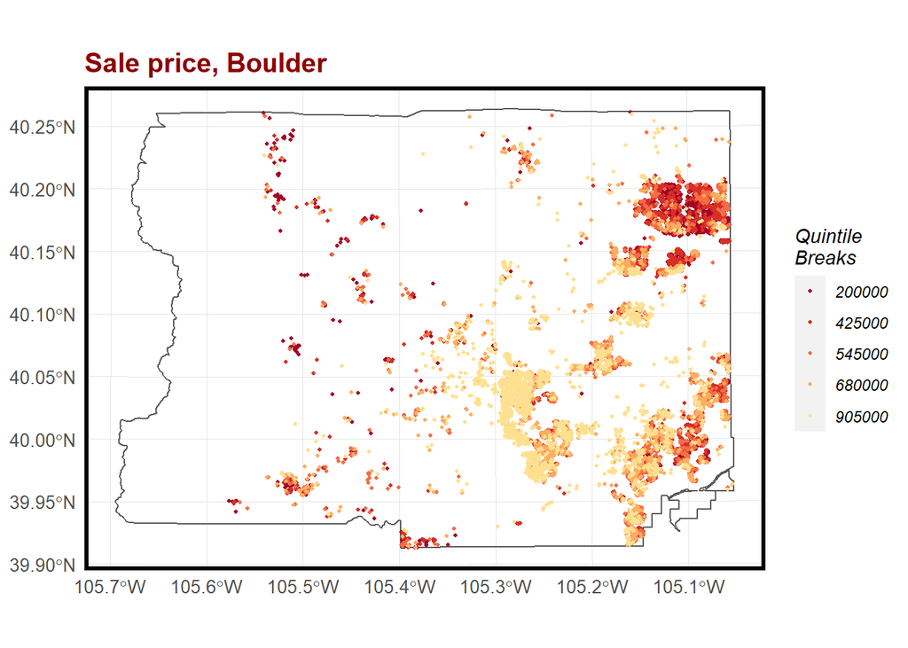

```r
ggplot() +
  geom_sf(data = boulder.boundary, fill = "transparent") +
  geom_sf(data = train_data, aes(colour = q5(price)),
          show.legend = "point", size = .75) +
  scale_colour_manual(values = palette,
                      labels=qBr(train_data,"price"),
                      name="Quintile\nBreaks") +
  labs(title="Sale price, Boulder") +
  mapTheme() +
  plotTheme()
```

### 2.5.2 map of independent variables

In this step, we visualized the most interesting independent variables: total finished squre feet,house area,percentage of vacant house and average distance to five nearest restaurants.

From the four maps and the former map of dependent variable,our finds are descriped as follow: IN the following map, the darker the color is, the lower the squre feet of the house. Which means the houses locate in center city tend to have more total finished squre feet.

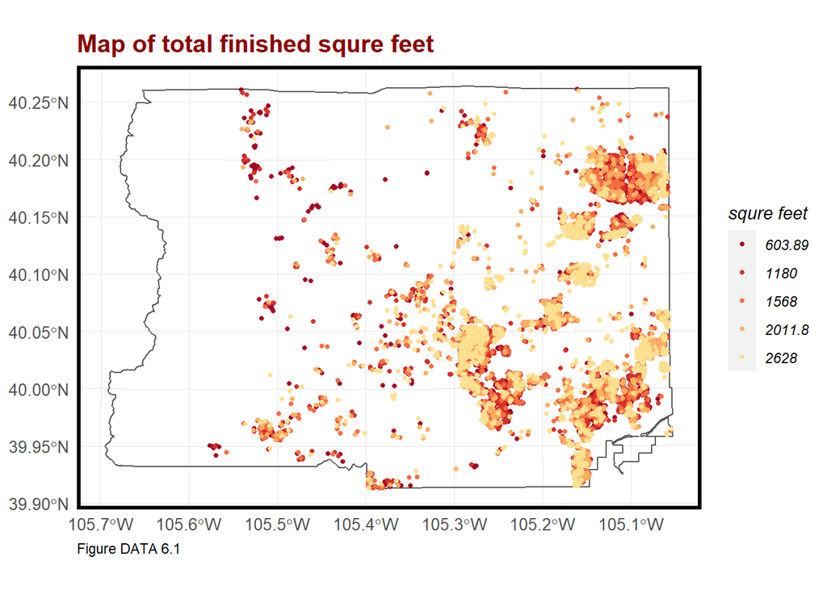

```r
ggplot() +
    geom_sf(data=boulder.boundary,fill="transparent") +
  geom_sf(data=train_data,aes(color = q5(TotalFinishedSF)),size = 1) +
  scale_color_manual(values =palette,
                     labels = qBr(train_data,'TotalFinishedSF'),
                     name = "squre feet") +
  labs(title = 'Map of total finished squre feet',
       caption = 'Figure DATA 6.1') +
  mapTheme() +
  plotTheme()
```

From the map below, we can see that the main floor squre feet, that is the house area goes up as the color turns light. Whe house located in the center and the north east and south east tends to have more area.

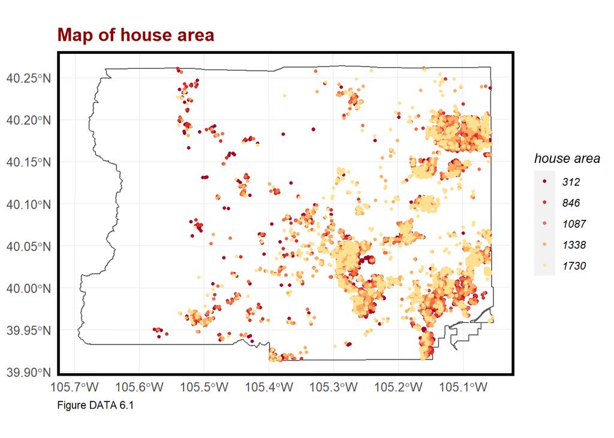

```r
ggplot() +
    geom_sf(data=boulder.boundary,fill="transparent") +
  geom_sf(data=train_data,aes(color = q5(mainfloorSF)),size = 1) +
  scale_color_manual(values =palette,labels = qBr(train_data,'mainfloorSF'),name = "house area") +labs(title = 'Map of house area',
       caption = 'Figure DATA 6.1') +
  mapTheme() +
  plotTheme()
```

From the map below, the lighter the color is, the more vacant house there are. The map show astonishing tendency that nearly all the houses in western part of the county have higher vancancy rate. While the house in the east part are occupied.I think maybe it’s because the abundant natural resources in the western county, most wealthy people bought the house but they don’t live there in their daily life. They’d like to have vacation here, so most of time, the house is vacant.

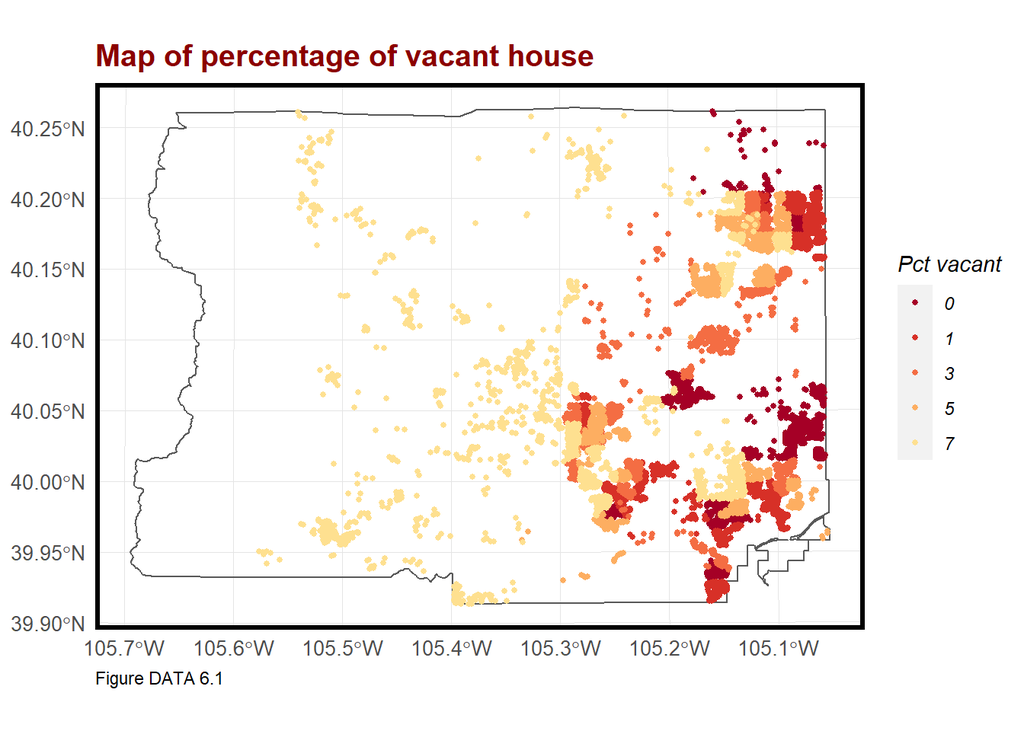

```r
ggplot() +
    geom_sf(data=boulder.boundary,fill="transparent") +
  geom_sf(data=train_data,aes(color = q5(pctTotalVacant)),size = 1) +
  scale_color_manual(values = palette,
                     labels = qBr(train_data,'pctTotalVacant'),
                     name = "Pct vacant")+
labs(title = 'Map of percentage of vacant house',
       caption = 'Figure DATA 6.1') +
  mapTheme() +
  plotTheme()
```

The map below show the average distance to five nearest restaurant. The darker the color is, the lower the distance is. In the center and north east and south east county, the distance is quite low, which means there are more restaurant around those districts, the amenity facility are more convenient.

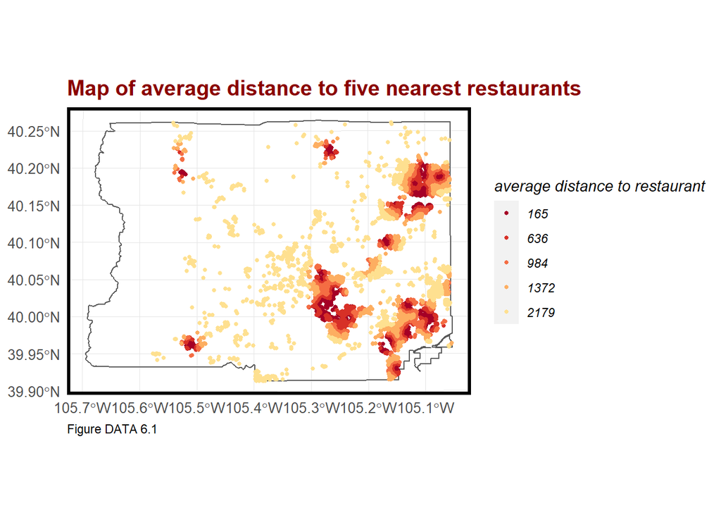

```r
ggplot() +
    geom_sf(data=boulder.boundary,fill="transparent") +
  geom_sf(data=train_data,aes(color = q5(restaurant_nn5)),size = 1) +
  scale_color_manual(values = palette,
                    labels = qBr(train_data,'restaurant_nn5'),
                     name = "average distance to restaurant")+
labs(title = 'Map of average distance to five nearest restaurants',
       caption = 'Figure DATA 6.1') +
  mapTheme() +
  plotTheme()
```

# **03. Methods**

This project adopted geospatial machine learning techniques, split housing the sale price data Our goal is to train the machine to predict house price with the existing data as accurate and generalized as possible. We firstly have to build a ordinary least squres regression model with several features,the try to adjust selected features to optimization model. But how could we know which model fit better?Then here comes the test work. With the provided datasets, we randomly split them into training and test datasets. Models will be trained on the former and tested on the latter. The training data occupies 75% of the all observations while testing data is 25%.  
In this multivariate case, the dependent variable is house price, while the independent variables are features we discussed above in section two. Based on the hedonic home price model, potential features encompass three components:internal features,neighborhood amenities/public services and the underlying spatial process of prices.  
After data wrangling and feature engineering work and correlation exploration, we finally got 59 features.We gradually narrow the range and finally got the features which altogether best predict the house price.  
The work flow of select the best fit features which give us the model with more accuracy and generalizability.We map,plot,make comparison with the following parameters of the model.  
MAE: Mean Absolute Error (MAE):calculated by taking the mean of the absolute values of subtracting each predicted housing prices from the corresponding given prices in the testing dataset.  
MAPE: Mean Absolute Percent Error (MAPE):the mean of Absolute Percent Error of each validation pairs - the difference between predicted and observed prices on a percentage basis.  
R-squared:in this case,it means that how much difference the features in regression model has made to make the prediction closer to the real house price.  
MSE: Mean Squared Error ,the averaged deviation from the correct values for the whole dataset.  
RMSE: Root Mean Squared Error,the square root of MSE, which is a measure the distribution of the residual.  
After consider the parameters, we can get the final model. Then we use k-fold cross validation to see whether the model is generalized or not, whether the residual are spatial correlated or not.

# **04. Results**

## 4.1 Dataset Splitting and Model Building

the dataset was divided into training set and test set, with the ratio of 3:1.

```r
# 1. Split dataset
set.seed(36)
# get index for training sample
inTrain <- caret::createDataPartition(
  y = (train_data$MUSA_ID),
  p = 0.75 , list = FALSE)

# split data into training and test
model_train <- train_data[inTrain,]
model_test<- train_data[-inTrain,]
```

```r
## Model 1 : only with internal features
M1 <- lm(price ~.,  data=st_drop_geometry(model_train)%>%
          select(price,designCode,
            qualityCode,EffectiveYear,nbrBedRoom,mainfloorSF,landmark_nn2,
 health_nn1, Tra_station_nn5, Openspace_nn5, Area_Trail_nn4,pctRenterOccupied,pctTotalVacant,pctWhite,pctPoverty,library_nn3 ))

#加入MedHHInc
M1.1 <- lm(price ~.,  data=st_drop_geometry(model_train)%>%
          select(price,designCode,
            qualityCode,EffectiveYear,nbrBedRoom,mainfloorSF,landmark_nn2,
 health_nn1, Tra_station_nn5, Openspace_nn5, Area_Trail_nn4,pctRenterOccupied,pctTotalVacant,pctWhite,pctPoverty,library_nn3,MedHHInc ))


M1.2<- lm(model_train$price ~.,  data=st_drop_geometry(model_train)%>%
          select(pctRenterOccupied,pctWhite,pctTotalVacant,MedHHInc,bsmtSF,carStorageSF,nbrThreeQtrBaths,qualityCode,EffectiveYear,nbrBedRoom,designCode,health_nn1,landmark_nn5,Openspace_nn5,Tra_station_nn2 ))


M2 <- lm(price ~.,  data=st_drop_geometry(model_train)%>%
          select(price,
            qualityCode,EffectiveYear,mainfloorSF,
 health_nn1,designCode,school_nn3,theater_nn2,
Tra_station_nn2, Openspace_nn5, MedHHInc,
nbrBedRoom,landmark_nn2,  restaurant_nn5,
 health_nn1, Tra_station_nn5, Openspace_nn5,
school_nn3,theater_nn2,TotalOccupied,restaurant_nn3,
Area_Trail_nn4,pctRenterOccupied,pctTotalVacant,pctWhite,pctPoverty,library_nn3))

M3 <- lm(price ~.,  data=st_drop_geometry(model_train)%>%
          select(price,TotalFinishedSF,
            qualityCode,EffectiveYear,nbrBedRoom,mainfloorSF,
 health_nn1,
Tra_station_nn5, Openspace_nn5, Area_Trail_nn4,pctTotalVacant,pctWhite,pctPoverty     ))

M4<- lm(price ~.,  data=st_drop_geometry(model_train)%>%
          select(price,
            qualityCode,EffectiveYear,nbrBedRoom,mainfloorSF,landmark_nn5,  health_nn5,
Tra_station_nn3, Openspace_nn5,pctTotalVacant,pctPoverty  ))

M5<- lm(price ~.,  data=st_drop_geometry(model_train)%>%
          select(price,
            qualityCode,designCode,EffectiveYear,nbrBedRoom,mainfloorSF,landmark_nn5,  health_nn5,
Tra_station_nn3, Openspace_nn5,pctTotalVacant,pctPoverty  ))
```

After comparation, the final model we choose is model 2, here is the summary of this model.

```r
stargazer(M2, type = "html",
          title = "Table 4.1 Summary Statistics of Model 2 ",
          header = FALSE,
          single.row = TRUE)
```

**Table 4.1 Summary Statistics of Model 2**

|  | *Dependent variable:* |
| --- | --- |
|  | price |
| qualityCode | 29,496.110*** (805.705) |
| EffectiveYear | -783.717*** (301.460) |
| mainfloorSF | 179.583*** (10.450) |
| health_nn1 | -5.507 (3.932) |
| designCode0020 | 117,067.700*** (11,762.100) |
| designCode0040 | 25,156.720 (25,635.660) |
| designCode0050 | 65,197.400*** (17,274.310) |
| designCode0120 | -43,645.260** (17,645.060) |
| school_nn3 | 0.647 (4.527) |
| theater_nn2 | 0.048 (1.586) |
| Tra_station_nn2 | -124.827*** (14.603) |
| Openspace_nn5 | 70.988*** (6.855) |
| MedHHInc | -0.245 (0.329) |
| nbrBedRoom | 16,979.710*** (4,808.465) |
| landmark_nn2 | -40.645*** (2.995) |
| restaurant_nn5 | -5.177 (28.050) |
| Tra_station_nn5 | 111.354*** (15.025) |
| TotalOccupied | -23.184*** (5.437) |
| restaurant_nn3 | -14.070 (29.002) |
| Area_Trail_nn4 | 53.178*** (10.068) |
| pctRenterOccupied | -150,271.500*** (29,562.780) |
| pctTotalVacant | 4,143.485*** (1,043.636) |
| pctWhite | -138,042.400** (62,523.550) |
| pctPoverty | 179,307.100** (88,381.030) |
| library_nn3 | -42.296*** (3.055) |
| Constant | 1,490,557.000** (589,962.500) |
| Observations | 8,448 |
| R<sup>2</sup> | 0.546 |
| Adjusted R<sup>2</sup> | 0.545 |
| Residual Std. Error | 373,185.000 (df = 8422) |
| F Statistic | 405.437*** (df = 25; 8422) |
| *Note:* | p<0.1; p<0.05; p<0.01 |

we choose the M2 model as the final model. And model summaries is shown below.

```r
training_model_final<-M2
summary(M2)
```

[output not shown]

## 4.2 training set of summary results

```r
# 2. Table of model summary on my training set
stargazer(training_model_final,
          type = "html",
          title = " Summary Statistics of Baseline Model on Training Set",
          header = FALSE,
          single.row = TRUE)
```

**Summary Statistics of Baseline Model on Training Set**

|  | *Dependent variable:* |
| --- | --- |
|  | price |
| qualityCode | 29,496.110*** (805.705) |
| EffectiveYear | -783.717*** (301.460) |
| mainfloorSF | 179.583*** (10.450) |
| health_nn1 | -5.507 (3.932) |
| designCode0020 | 117,067.700*** (11,762.100) |
| designCode0040 | 25,156.720 (25,635.660) |
| designCode0050 | 65,197.400*** (17,274.310) |
| designCode0120 | -43,645.260** (17,645.060) |
| school_nn3 | 0.647 (4.527) |
| theater_nn2 | 0.048 (1.586) |
| Tra_station_nn2 | -124.827*** (14.603) |
| Openspace_nn5 | 70.988*** (6.855) |
| MedHHInc | -0.245 (0.329) |
| nbrBedRoom | 16,979.710*** (4,808.465) |
| landmark_nn2 | -40.645*** (2.995) |
| restaurant_nn5 | -5.177 (28.050) |
| Tra_station_nn5 | 111.354*** (15.025) |
| TotalOccupied | -23.184*** (5.437) |
| restaurant_nn3 | -14.070 (29.002) |
| Area_Trail_nn4 | 53.178*** (10.068) |
| pctRenterOccupied | -150,271.500*** (29,562.780) |
| pctTotalVacant | 4,143.485*** (1,043.636) |
| pctWhite | -138,042.400** (62,523.550) |
| pctPoverty | 179,307.100** (88,381.030) |
| library_nn3 | -42.296*** (3.055) |
| Constant | 1,490,557.000** (589,962.500) |
| Observations | 8,448 |
| R<sup>2</sup> | 0.546 |
| Adjusted R<sup>2</sup> | 0.545 |
| Residual Std. Error | 373,185.000 (df = 8422) |
| F Statistic | 405.437*** (df = 25; 8422) |
| *Note:* | p<0.1; p<0.05; p<0.01 |

```r
broom::glance(training_model_final) %>%
  kable(caption = ' Summary of Model Evaluation Parameters') %>%
  kable_styling("striped",stripe_color = "gray!6" ,full_width = F)
```

Summary of Model Evaluation Parameters

| r.squared | adj.r.squared | sigma | statistic | p.value | df | logLik | AIC | BIC | deviance | df.residual | nobs |
| --- | --- | --- | --- | --- | --- | --- | --- | --- | --- | --- | --- |
| 0.5461776 | 0.5448304 | 373185 | 405.4368 | 0 | 25 | -120360.6 | 240775.1 | 240965.3 | 1172907325076101 | 8422 | 8448 |

## 4.3 table of MAE and MAPE for test set

The model returns a MAE $194219.5,while the MAPE suggest the model errs by 30%,(0.3088744).When we change features and try to optimize the final model, we found that although we added some significant features, some time the MAPE still increase,the 31% is our final least result.

```r
# 3. MAE, MAPE on test set

model_test2 <- model_test %>%
mutate(Regression = "Baseline Regression",
         SalePrice.Predict  = predict(M2, newdata = model_test),
         SalePrice.Error = price - SalePrice.Predict,
          SalePrice.AbsError = abs(price - SalePrice.Predict),
         SalePrice.APE  = abs(price - SalePrice.Predict) / price)%>%
  filter(price < 5000000)

mean(model_test2$SalePrice.APE, na.rm = T)
```

```
## [1] 0.3088744
```

```r
generalization<-as.data.frame(cbind(mean(model_test2$SalePrice.AbsError,na.rm = T),
                                    mean(model_test2$SalePrice.APE,na.rm = T)))

colnames(generalization)<-c("Mean Absolute Errors (MAE)","MAPE")

kable(generalization,
      caption = ' MAE and MAPE for Test Set') %>%
  kable_styling("striped", stripe_color = "gray!6",full_width = F)
```

MAE and MAPE for Test Set

| Mean Absolute Errors (MAE) | MAPE |
| --- | --- |
| 194219.5 | 0.3088744 |

## 4.4 cross-validation tests

```r
##  use caret package cross-validation method

fitControl <- caret:: trainControl(method = "cv", number = 100,savePredictions = TRUE)
set.seed(233)

mode2.cv <-
caret::train(price ~ .,data = st_drop_geometry(train_data) %>%
                 dplyr::select(
        price,
            qualityCode,EffectiveYear,mainfloorSF,
 health_nn1,designCode,school_nn3,theater_nn2,
Tra_station_nn2, Openspace_nn5, MedHHInc,
nbrBedRoom,landmark_nn2,  restaurant_nn5,
 health_nn1, Tra_station_nn5, Openspace_nn5,
school_nn3,theater_nn2,TotalOccupied,restaurant_nn3,
Area_Trail_nn4,pctRenterOccupied,pctTotalVacant,pctWhite,pctPoverty,library_nn3) ,
 method = "lm", trControl = fitControl, na.action =  na.pass)

mode2.cv
```

```
## Linear Regression
##
## 11264 samples
##    22 predictor
##
## No pre-processing
## Resampling: Cross-Validated (100 fold)
## Summary of sample sizes: 11152, 11152, 11152, 11152, 11152, 11151, ...
## Resampling results:
##
##   RMSE      Rsquared   MAE
##   369290.8  0.5938779  207220.9
##
## Tuning parameter 'intercept' was held constant at a value of TRUE
```

```r
#mode2.cv$resample[1:5,]
#mean(mode2.cv$resample[,3]) #resample third column,MAE,mean absolute error.

## show RMSE, MAE, R^2
kable(mode2.cv$resample,
          caption = 'Cross-validation Test Summary ') %>%
  kable_styling("striped", full_width = F)
```

Cross-validation Test Summary

| RMSE | Rsquared | MAE | Resample |
| --- | --- | --- | --- |
| 313593.0 | 0.6503723 | 212784.5 | Fold001 |
| 195386.5 | 0.7248978 | 143049.4 | Fold002 |
| 264328.6 | 0.6867979 | 189219.1 | Fold003 |
| 339289.8 | 0.7243607 | 207197.3 | Fold004 |
| 283327.2 | 0.6483015 | 207078.8 | Fold005 |
| 412845.3 | 0.6606279 | 218493.6 | Fold006 |
| 330801.5 | 0.5129606 | 218973.7 | Fold007 |
| 259502.4 | 0.6223017 | 201957.3 | Fold008 |
| 219423.5 | 0.6924457 | 167781.3 | Fold009 |
| 225328.3 | 0.6796926 | 170661.7 | Fold010 |
| 419185.2 | 0.4914877 | 251073.3 | Fold011 |
| 415397.6 | 0.6610747 | 212249.1 | Fold012 |
| 283429.9 | 0.5486336 | 199214.7 | Fold013 |
| 278218.5 | 0.6058513 | 200194.4 | Fold014 |
| 228865.5 | 0.7110058 | 163082.5 | Fold015 |
| 2965583.6 | 0.0217374 | 503281.4 | Fold016 |
| 541903.2 | 0.4848768 | 252166.3 | Fold017 |
| 291145.8 | 0.6930585 | 194076.7 | Fold018 |
| 314517.0 | 0.6523394 | 207548.1 | Fold019 |
| 308585.8 | 0.6952240 | 186037.4 | Fold020 |
| 285452.1 | 0.6715779 | 216246.5 | Fold021 |
| 333185.7 | 0.5223987 | 213388.3 | Fold022 |
| 283011.0 | 0.6311137 | 188900.4 | Fold023 |
| 263605.9 | 0.6331214 | 179015.2 | Fold024 |
| 322145.6 | 0.5941220 | 198960.3 | Fold025 |
| 682135.7 | 0.1710752 | 234514.3 | Fold026 |
| 214698.5 | 0.6314766 | 163560.0 | Fold027 |
| 281963.0 | 0.5897557 | 199743.0 | Fold028 |
| 264315.3 | 0.6683262 | 167212.7 | Fold029 |
| 214294.2 | 0.7136424 | 164751.2 | Fold030 |

[output cut: 70 more lines]

```r
kable(mode2.cv$resample[1:5,],
      caption = 'Cross-valviewidation Test Summary in first 5 output ') %>%
  kable_styling("striped", full_width = F)
```

Cross-valviewidation Test Summary in first 5 output

| RMSE | Rsquared | MAE | Resample |
| --- | --- | --- | --- |
| 313593.0 | 0.6503723 | 212784.5 | Fold001 |
| 195386.5 | 0.7248978 | 143049.4 | Fold002 |
| 264328.6 | 0.6867979 | 189219.1 | Fold003 |
| 339289.8 | 0.7243607 | 207197.3 | Fold004 |
| 283327.2 | 0.6483015 | 207078.8 | Fold005 |

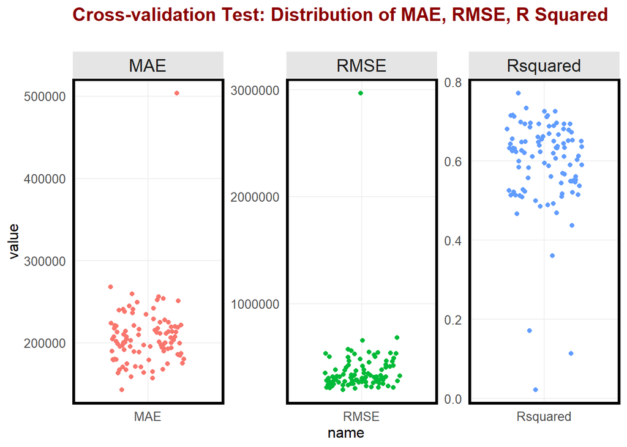

```r
mode2.cv$resample %>%
  pivot_longer(-Resample) %>%
  mutate(name = as.factor(name)) %>%
  ggplot(., aes(x = name, y = value, color = name)) +
  geom_jitter(width = 0.3) +
  facet_wrap(~name, ncol = 3, scales = "free") +
 theme_minimal(
  base_size = 11,
  base_family = "",
  base_line_size = 0.5,
  base_rect_size = 0.5
) +
  theme(legend.position = "none") +
  labs(title = 'Cross-validation Test: Distribution of MAE, RMSE, R Squared\n') +
  plotTheme()
```

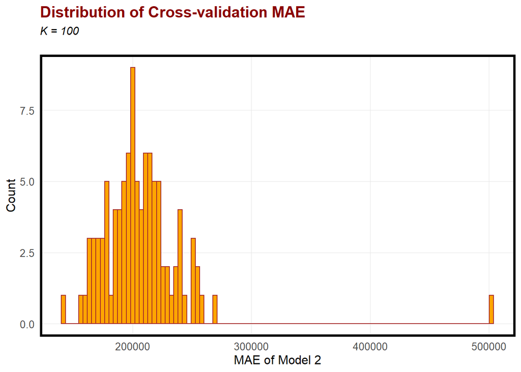

```r
ggplot(data = mode2.cv$resample) +
  geom_histogram(bins = 100,aes(x = mode2.cv$resample$MAE),color='brown' ,fill = 'orange') +
  labs(title="Distribution of Cross-validation MAE",
       subtitle = "K = 100\n") +
  xlab('MAE of Model 2') +
  ylab('Count') +
  plotTheme()
```